# Lab 2: Data Understanding & Exploratory Data Analysis

- Show All Code
- Hide All Code
- View Source

CRISP-DM Phase 2 — Carseats-Case

Author

Prof. Dr. Jörg Schoder

Published

March 18, 2026

## 1 Learning Objectives and Overview

**NoteLearning Objectives**

**Szenario:** Sie sind Data Scientist einer Handelskette mit 400 Filialen. Bevor Sie ein Modell bauen, müssen Sie die Daten verstehen — das ist CRISP-DM Phase 2: **Data Understanding**.

**TipZeitplanung**

⏱ **20 Minuten** — Pflichtaufgaben (A1–A4) zuerst, Bonusaufgaben wenn Zeit bleibt.

## 2 Hintergrund: Warum EDA zuerst?

### 2.1 Das Datasaurus-Problem

Schauen Sie sich folgende Datensätze an:

```r
library(datasauRus)

# Deskriptive Statistiken aller 13 Datensätze
datasaurus_dozen %>%
  group_by(dataset) %>%
  summarise(
    n       = n(),
    mean_x  = round(mean(x), 2),
    mean_y  = round(mean(y), 2),
    sd_x    = round(sd(x),   2),
    sd_y    = round(sd(y),   2),
    cor_xy  = round(cor(x, y), 2)
  ) %>%
  gt() %>%
  tab_style(
    style     = cell_fill(color = "#fff8e1"),
    locations = cells_body(rows = dataset == "dino")
  ) %>%
  tab_options(table.font.size = "13px") %>%
  tab_footnote("Alle Datensätze haben (fast) identische deskriptive Statistiken!")
```

| dataset | n | mean_x | mean_y | sd_x | sd_y | cor_xy |
| --- | --- | --- | --- | --- | --- | --- |
| away | 142 | 54.27 | 47.83 | 16.77 | 26.94 | -0.06 |
| bullseye | 142 | 54.27 | 47.83 | 16.77 | 26.94 | -0.07 |
| circle | 142 | 54.27 | 47.84 | 16.76 | 26.93 | -0.07 |
| dino | 142 | 54.26 | 47.83 | 16.77 | 26.94 | -0.06 |
| dots | 142 | 54.26 | 47.84 | 16.77 | 26.93 | -0.06 |
| h_lines | 142 | 54.26 | 47.83 | 16.77 | 26.94 | -0.06 |
| high_lines | 142 | 54.27 | 47.84 | 16.77 | 26.94 | -0.07 |
| slant_down | 142 | 54.27 | 47.84 | 16.77 | 26.94 | -0.07 |
| slant_up | 142 | 54.27 | 47.83 | 16.77 | 26.94 | -0.07 |
| star | 142 | 54.27 | 47.84 | 16.77 | 26.93 | -0.06 |
| v_lines | 142 | 54.27 | 47.84 | 16.77 | 26.94 | -0.07 |
| wide_lines | 142 | 54.27 | 47.83 | 16.77 | 26.94 | -0.07 |
| x_shape | 142 | 54.26 | 47.84 | 16.77 | 26.93 | -0.07 |

Alle Datensätze haben (fast) identische deskriptive Statistiken!

**ImportantDie zentrale Botschaft**

Alle 13 Datensätze haben **fast identische** Mittelwerte, Standardabweichungen und Korrelationen — aber sehen Sie selbst:

**Code anzeigen**

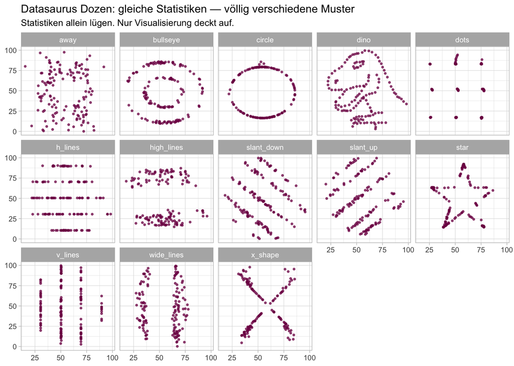

```r
datasaurus_dozen %>%
  ggplot(aes(x, y)) +
  geom_point(size = 0.6, color = "#7d0a52", alpha = 0.7) +
  facet_wrap(~dataset, nrow = 3) +
  theme_light(base_size = 9) +
  labs(
    title    = "Datasaurus Dozen: gleiche Statistiken — völlig verschiedene Muster",
    subtitle = "Statistiken allein lügen. Nur Visualisierung deckt auf.",
    x = NULL, y = NULL
  )
```

**Fazit:** Vor jeder Regression steht die EDA. Statistiken allein sind unzureichend.

### 2.2 Elemente explorativer Datenanalyse

1. **Inhaltliche Bedeutung** — Es geht primär um substanzielles Verständnis von Variablen und deren möglichen Zusammenhängen, nicht um formale Tests.
2. **Grafische Darstellung** — Betonung der visuellen Inspektion von Variablen und Datenmengen als primäres Erkenntnismittel.
3. **Iterative Modellbildung** — Schwerpunkt liegt auf versuchsweiser Hypothesengenerierung in einem iterativen Prozess der Modellspezifikation und -neuspezifikation.
4. **Skeptizismus und Sparsamkeit** — Ausgangspunkte sind Skepsis, Flexibilität und Sparsamkeit bezüglich der anzuwendenden statistischen Methoden.

**NoteEDA als CRISP-DM Phase 2**

In unserem Carseats-Projekt dient die EDA dazu, **Hypothesen** für die Modellierung zu generieren: Welche Variablen erklären die Umsatzunterschiede zwischen Filialen? Welche Transformationen sind nötig? Gibt es Ausreißer oder Muster?

## 3 Schritt 1: Datensatz kennenlernen

### 3.1 Überblick: Struktur und Variablen

```r
glimpse(tbl_carseats)
```

```
Rows: 400
Columns: 11
$ Sales       <dbl> 9.50, 11.22, 10.06, 7.40, 4.15, 10.81, 6.63, 11.85, 6.54, …
$ CompPrice   <dbl> 138, 111, 113, 117, 141, 124, 115, 136, 132, 132, 121, 117…
$ Income      <dbl> 73, 48, 35, 100, 64, 113, 105, 81, 110, 113, 78, 94, 35, 2…
$ Advertising <dbl> 11, 16, 10, 4, 3, 13, 0, 15, 0, 0, 9, 4, 2, 11, 11, 5, 0, …
$ Population  <dbl> 276, 260, 269, 466, 340, 501, 45, 425, 108, 131, 150, 503,…
$ Price       <dbl> 120, 83, 80, 97, 128, 72, 108, 120, 124, 124, 100, 94, 136…
$ ShelveLoc   <fct> Bad, Good, Medium, Medium, Bad, Bad, Medium, Good, Medium,…
$ Age         <dbl> 42, 65, 59, 55, 38, 78, 71, 67, 76, 76, 26, 50, 62, 53, 52…
$ Education   <dbl> 17, 10, 12, 14, 13, 16, 15, 10, 10, 17, 10, 13, 18, 18, 18…
$ Urban       <fct> Yes, Yes, Yes, Yes, Yes, No, Yes, Yes, No, No, No, Yes, Ye…
$ US          <fct> Yes, Yes, Yes, Yes, No, Yes, No, Yes, No, Yes, Yes, Yes, N…
```

**TipInterpretation**

- Wie viele Beobachtungen (Filialen) und Variablen hat der Datensatz?
- Welche Variablen sind numerisch (`dbl`), welche kategorisch (`chr`/`fct`)?
- Was bedeutet `Sales` genau? (Einheit beachten!)

### 3.2 Zusammenfassende Statistiken

**Code anzeigen**

```r
tbl_carseats %>%
  select(Sales, Price, Advertising, Income, Age, ShelveLoc, Urban, US) %>%
  skim() %>%
  yank("numeric") %>%
  gt() %>%
  fmt_number(columns = where(is.numeric), decimals = 2) %>%
  tab_options(table.font.size = "13px")
```

| skim_variable | n_missing | complete_rate | mean | sd | p0 | p25 | p50 | p75 | p100 | hist |
| --- | --- | --- | --- | --- | --- | --- | --- | --- | --- | --- |
| Sales | 0.00 | 1.00 | 7.50 | 2.82 | 0.00 | 5.39 | 7.49 | 9.32 | 16.27 | ▁▆▇▃▁ |
| Price | 0.00 | 1.00 | 115.79 | 23.68 | 24.00 | 100.00 | 117.00 | 131.00 | 191.00 | ▁▂▇▆▁ |
| Advertising | 0.00 | 1.00 | 6.64 | 6.65 | 0.00 | 0.00 | 5.00 | 12.00 | 29.00 | ▇▃▃▁▁ |
| Income | 0.00 | 1.00 | 68.66 | 27.99 | 21.00 | 42.75 | 69.00 | 91.00 | 120.00 | ▇▆▇▆▅ |
| Age | 0.00 | 1.00 | 53.32 | 16.20 | 25.00 | 39.75 | 54.50 | 66.00 | 80.00 | ▇▆▇▇▇ |

**Caution A1: Datensatz erkunden**

1. Wie viele Filialen (`n`) enthält der Datensatz?
2. Welchen **Wertebereich** hat `Sales` (Min, Max)? Was bedeutet das inhaltlich?
3. Welchen **Wertebereich** hat `Price`? Ist der Carseats-Markt preiselastisch?
4. Was bedeutet die Variable `ShelveLoc`? Welche Ausprägungen hat sie?

```r
# Häufigkeitstabelle für kategorische Variable
tbl_carseats %>% count(ShelveLoc)
tbl_carseats %>% count(Urban)
tbl_carseats %>% count(US)
```

## 4 Schritt 2: Verteilung der Zielvariable Sales

### 4.1 Histogramm der Rohdaten

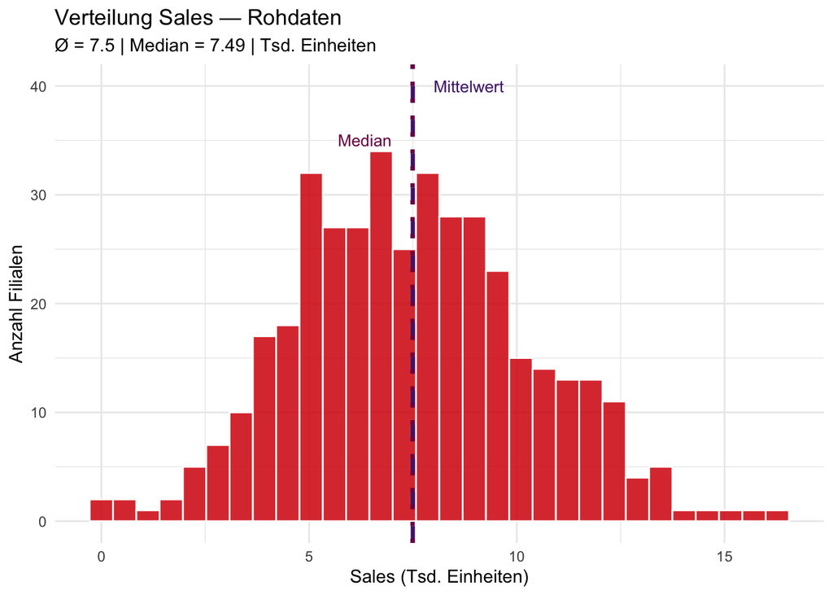

```r
p1 <- tbl_carseats %>%
  ggplot(aes(x = Sales)) +
  geom_histogram(bins = 30, fill = "#D50006", color = "white", alpha = 0.85) +
  geom_vline(xintercept = mean(tbl_carseats$Sales),
             color = "#502479", linewidth = 1.2, linetype = "dashed") +
  geom_vline(xintercept = median(tbl_carseats$Sales),
             color = "#7d0a52", linewidth = 1.2, linetype = "dotted") +
  annotate("text", x = mean(tbl_carseats$Sales) + 0.5,
           y = 40, label = "Mittelwert",
           color = "#502479", size = 3.5, hjust = 0) +
  annotate("text", x = median(tbl_carseats$Sales) - 0.5,
           y = 35, label = "Median",
           color = "#7d0a52", size = 3.5, hjust = 1) +
  labs(
    title    = "Verteilung Sales — Rohdaten",
    subtitle = paste0("Ø = ", round(mean(tbl_carseats$Sales), 2),
                      " | Median = ", round(median(tbl_carseats$Sales), 2),
                      " | Tsd. Einheiten"),
    x = "Sales (Tsd. Einheiten)", y = "Anzahl Filialen"
  ) +
  theme_minimal(base_size = 11)

p1
```